# Lesson3-7-27-2023

## Some Interesting Extensions

Our data are large and inherently seasonal. One way we might want to visualize the seasonal patterns of stream flow might be with a boxplot. Here is an example:

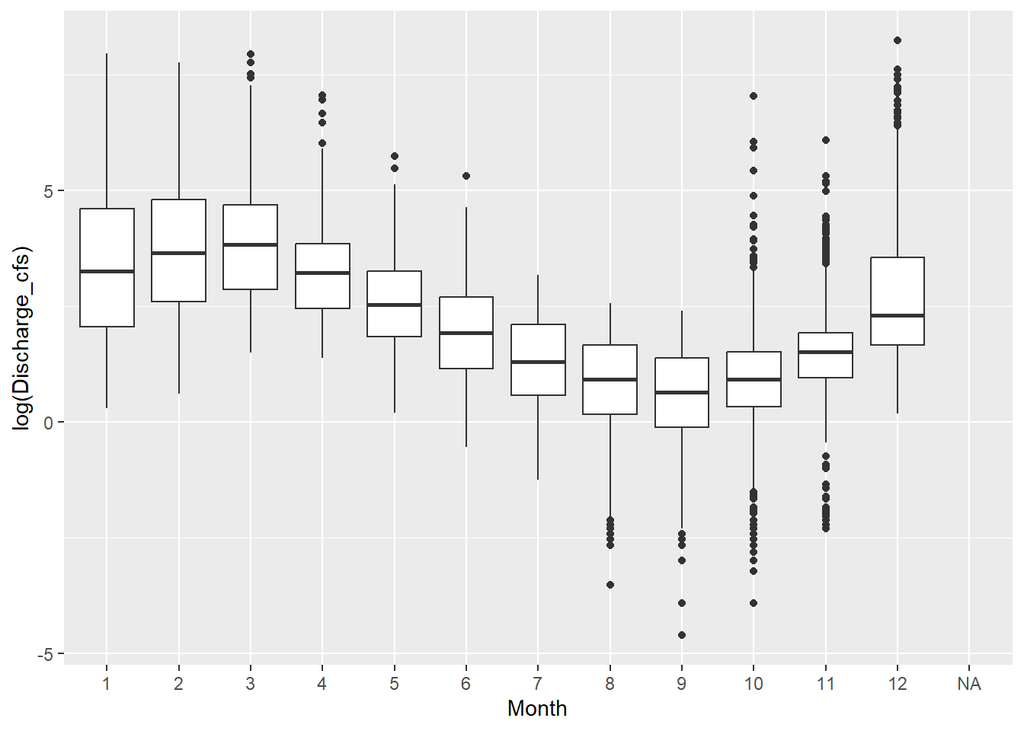

```r
# Create a month variable using dplyr syntax
soquel <- soquel %>% mutate(month=as.numeric(format(Date,"%m")))

# Create a boxplot organized by month
ggplot(data=soquel,aes(x=factor(month),y=log(Discharge_cfs))) + geom_boxplot() + xlab("Month")
```

A couple things to note here:

1. R allows us to nest operations.
   - the syntax `x=factor(month)` is using the `factor()` method to convert the month variable from numeric to a factor for the purposes of plotting
   - the syntax `y=log(Discharge_cfs)` is using the `log()` transform to adjust the scale of the y-axis values.
2. Using the `ggplot()` package we can label our plot axes using the syntax `xlab()` and `ylab()`